# Julius’s Final Project

The csv file we are working with is large but no where near “big data” or anything like that. It is a summary of electricity generation and trade in the USA. Originally the idea was to specifically analyze Nuclear Power, but analyzing electricity in general has much more data and is more interesting. In each row, the information we are analyzing is the Year/Month, Value, and Description. From this we will analyze how the value (which is billions of kilowatt hours) are related to what month of the year it is, trends over time, generation per sector for the time of year, trends about trade, and other analyses described later in comments. This data is a summary from https://www.eia.gov/electricity/data.php

A link to a pdf: https://www.eia.gov/totalenergy/data/monthly/pdf/sec7_3.pdf

```r
data = read.csv(file.choose(), header = TRUE)
data
```

```
##         MSN YYYYMM    Value Column_Order
## 1   ELEGPUS 194913    291.1            1
## 2   ELEGPUS 195013  329.141            1
## 3   ELEGPUS 195113  370.673            1
## 4   ELEGPUS 195213  399.224            1
## 5   ELEGPUS 195313  442.665            1
## 6   ELEGPUS 195413  471.686            1
## 7   ELEGPUS 195513  547.038            1
## 8   ELEGPUS 195613  600.668            1
## 9   ELEGPUS 195713  631.517            1
## 10  ELEGPUS 195813  645.098            1
## 11  ELEGPUS 195913  710.006            1
## 12  ELEGPUS 196013  755.549            1
## 13  ELEGPUS 196113   793.76            1
## 14  ELEGPUS 196213  854.535            1
```

[output cut: 320 more lines]

```r
library(tidyr)
library(purrr)
library(ggplot2)
library(dplyr)
library(rmarkdown)
```

This is importing the file and loading the libraries we are going to use

```r
data[,3] <- as.numeric(as.character(unlist(data[[3]])))
data <- na.omit(data)
data <- compact(data)
data
```

```
##         MSN YYYYMM    Value Column_Order
## 1   ELEGPUS 194913  291.100            1
## 2   ELEGPUS 195013  329.141            1
## 3   ELEGPUS 195113  370.673            1
## 4   ELEGPUS 195213  399.224            1
## 5   ELEGPUS 195313  442.665            1
## 6   ELEGPUS 195413  471.686            1
## 7   ELEGPUS 195513  547.038            1
## 8   ELEGPUS 195613  600.668            1
## 9   ELEGPUS 195713  631.517            1
## 10  ELEGPUS 195813  645.098            1
## 11  ELEGPUS 195913  710.006            1
## 12  ELEGPUS 196013  755.549            1
## 13  ELEGPUS 196113  793.760            1
## 14  ELEGPUS 196213  854.535            1
```

[output cut: 320 more lines]

This cleans up the values column and removes non-data

```r
spData <- spread(data,Description,Value)
spData
```

```
##        MSN YYYYMM Column_Order                  Unit Electricity Direct Use
## 1  ELC5PUS 198901            2 Billion Kilowatthours                     NA
## 2  ELC5PUS 198902            2 Billion Kilowatthours                     NA
## 3  ELC5PUS 198903            2 Billion Kilowatthours                     NA
## 4  ELC5PUS 198904            2 Billion Kilowatthours                     NA
## 5  ELC5PUS 198905            2 Billion Kilowatthours                     NA
## 6  ELC5PUS 198906            2 Billion Kilowatthours                     NA
## 7  ELC5PUS 198907            2 Billion Kilowatthours                     NA
## 8  ELC5PUS 198908            2 Billion Kilowatthours                     NA
## 9  ELC5PUS 198909            2 Billion Kilowatthours                     NA
## 10 ELC5PUS 198910            2 Billion Kilowatthours                     NA
## 11 ELC5PUS 198911            2 Billion Kilowatthours                     NA
## 12 ELC5PUS 198912            2 Billion Kilowatthours                     NA
## 13 ELC5PUS 198913            2 Billion Kilowatthours                     NA
## 14 ELC5PUS 199001            2 Billion Kilowatthours                     NA
```

[output cut: 455 more lines]

```r
spDreset <- spData
```

Using spread allows us to separate the values by Description

```r
dYearTotal <- keep(spData[,2],substr(data[,2],5,7) == "13")
dYearTotal
```

```
##   [1] 198901 198902 198903 198904 198905 198906 198907 198908 198909 198910 198911 198912
##  [13] 198913 199001 199002 199003 199004 199005 199006 199007 199008 199009 199010 199011
##  [25] 199111 199211 199311 199411 199511 199611 199711 199811 199911 200011 200111 200211
##  [37] 200311 200411 200511 200611 200711 200811 200911 201011 201111 201211 201311 201411
##  [49] 201511 201611 201711 201811 201911 198903 199003 199103 199203 199303 199403 199503
##  [61] 199603 199703 199803 199903 200003 200103 200203 200303 200403 200503 200603 200711
##  [73] 200811 200911 201011 201111 201211 201311 201411 201511 201611 201711 201811 201911
##  [85] 195113 196413 197305 197405 197505 197605 197705 197805 197905 198005 198105 198205
##  [97] 198305 198405 198505 198605 198705 198805 198901 198902 198903 198904 198905 198906
## [109] 198907 198908 198909 198910 198911 198912 198913 199001 199002 199003 199004 199005
## [121] 199006 199007 199008 199009 199010 199011 199111 199211 199311 199411 199511 199611
## [133] 199711 199811 199911 200011 200111 200211 200311 200411 200511 200611 200711 200811
## [145] 200911 201011 201111 201211 201311 201411 201511 201611 201711 201811 201911 195113
## [157] 196413 197305 197405 197505 197605 197705 197805 197905 198005 198105 198205 198305
## [169] 198405 198505 198605 198705 198805 198901 198902 198903 198904 198905 198906 198907
```

[output cut: 44 more lines]

```r
dMonths <- discard(data[,2],substr(data[,2],5,7) == "13")
dMonths
```

```
##    [1] 197301 197302 197303 197304 197305 197306 197307 197308 197309 197310 197311
##   [12] 197312 197401 197402 197403 197404 197405 197406 197407 197408 197409 197410
##   [23] 197411 197412 197501 197502 197503 197504 197505 197506 197507 197508 197509
##   [34] 197510 197511 197512 197601 197602 197603 197604 197605 197606 197607 197608
##   [45] 197609 197610 197611 197612 197701 197702 197703 197704 197705 197706 197707
##   [56] 197708 197709 197710 197711 197712 197801 197802 197803 197804 197805 197806
##   [67] 197807 197808 197809 197810 197811 197812 197901 197902 197903 197904 197905
##   [78] 197906 197907 197908 197909 197910 197911 197912 198001 198002 198003 198004
##   [89] 198005 198006 198007 198008 198009 198010 198011 198012 198101 198102 198103
##  [100] 198104 198105 198106 198107 198108 198109 198110 198111 198112 198201 198202
##  [111] 198203 198204 198205 198206 198207 198208 198209 198210 198211 198212 198301
##  [122] 198302 198303 198304 198305 198306 198307 198308 198309 198310 198311 198312
##  [133] 198401 198402 198403 198404 198405 198406 198407 198408 198409 198410 198411
##  [144] 198412 198501 198502 198503 198504 198505 198506 198507 198508 198509 198510
##  [155] 198511 198512 198601 198602 198603 198604 198605 198606 198607 198608 198609
```

[output cut: 77 more lines]

This is list of the same as above but for months

```r
dYearL <- substr(dYearTotal,1,4)
dYearL
```

```
##   [1] "1989" "1989" "1989" "1989" "1989" "1989" "1989" "1989" "1989" "1989" "1989" "1989"
##  [13] "1989" "1990" "1990" "1990" "1990" "1990" "1990" "1990" "1990" "1990" "1990" "1990"
##  [25] "1991" "1992" "1993" "1994" "1995" "1996" "1997" "1998" "1999" "2000" "2001" "2002"
##  [37] "2003" "2004" "2005" "2006" "2007" "2008" "2009" "2010" "2011" "2012" "2013" "2014"
##  [49] "2015" "2016" "2017" "2018" "2019" "1989" "1990" "1991" "1992" "1993" "1994" "1995"
##  [61] "1996" "1997" "1998" "1999" "2000" "2001" "2002" "2003" "2004" "2005" "2006" "2007"
##  [73] "2008" "2009" "2010" "2011" "2012" "2013" "2014" "2015" "2016" "2017" "2018" "2019"
##  [85] "1951" "1964" "1973" "1974" "1975" "1976" "1977" "1978" "1979" "1980" "1981" "1982"
##  [97] "1983" "1984" "1985" "1986" "1987" "1988" "1989" "1989" "1989" "1989" "1989" "1989"
## [109] "1989" "1989" "1989" "1989" "1989" "1989" "1989" "1990" "1990" "1990" "1990" "1990"
## [121] "1990" "1990" "1990" "1990" "1990" "1990" "1991" "1992" "1993" "1994" "1995" "1996"
## [133] "1997" "1998" "1999" "2000" "2001" "2002" "2003" "2004" "2005" "2006" "2007" "2008"
## [145] "2009" "2010" "2011" "2012" "2013" "2014" "2015" "2016" "2017" "2018" "2019" "1951"
## [157] "1964" "1973" "1974" "1975" "1976" "1977" "1978" "1979" "1980" "1981" "1982" "1983"
## [169] "1984" "1985" "1986" "1987" "1988" "1989" "1989" "1989" "1989" "1989" "1989" "1989"
```

[output cut: 44 more lines]

This is a list of the first four characters in the year column, which because it is YYYYMM we get the year

```r
dMonthL <- substr(dMonths,5,7)
dMonthL
```

```
##    [1] "01" "02" "03" "04" "05" "06" "07" "08" "09" "10" "11" "12" "01" "02" "03" "04"
##   [17] "05" "06" "07" "08" "09" "10" "11" "12" "01" "02" "03" "04" "05" "06" "07" "08"
##   [33] "09" "10" "11" "12" "01" "02" "03" "04" "05" "06" "07" "08" "09" "10" "11" "12"
##   [49] "01" "02" "03" "04" "05" "06" "07" "08" "09" "10" "11" "12" "01" "02" "03" "04"
##   [65] "05" "06" "07" "08" "09" "10" "11" "12" "01" "02" "03" "04" "05" "06" "07" "08"
##   [81] "09" "10" "11" "12" "01" "02" "03" "04" "05" "06" "07" "08" "09" "10" "11" "12"
##   [97] "01" "02" "03" "04" "05" "06" "07" "08" "09" "10" "11" "12" "01" "02" "03" "04"
##  [113] "05" "06" "07" "08" "09" "10" "11" "12" "01" "02" "03" "04" "05" "06" "07" "08"
##  [129] "09" "10" "11" "12" "01" "02" "03" "04" "05" "06" "07" "08" "09" "10" "11" "12"
##  [145] "01" "02" "03" "04" "05" "06" "07" "08" "09" "10" "11" "12" "01" "02" "03" "04"
##  [161] "05" "06" "07" "08" "09" "10" "11" "12" "01" "02" "03" "04" "05" "06" "07" "08"
##  [177] "09" "10" "11" "12" "01" "02" "03" "04" "05" "06" "07" "08" "09" "10" "11" "12"
##  [193] "01" "02" "03" "04" "05" "06" "07" "08" "09" "10" "11" "12" "01" "02" "03" "04"
##  [209] "05" "06" "07" "08" "09" "10" "11" "12" "01" "02" "03" "04" "05" "06" "07" "08"
##  [225] "09" "10" "11" "12" "01" "02" "03" "04" "05" "06" "07" "08" "09" "10" "11" "12"
```

[output cut: 49 more lines]

Same concept as above, though it takes the month (MM)

```r
expData <- arrange(data,desc(Value))
expData
```

```
##         MSN YYYYMM    Value Column_Order
## 1   ELETPUS 201813 4178.277            4
## 2   ELETPUS 200713 4156.745            4
## 3   ELETPUS 201913 4126.882            4
## 4   ELETPUS 201013 4125.060            4
## 5   ELETPUS 200813 4119.388            4
## 6   ELETPUS 201113 4100.141            4
## 7   ELETPUS 201413 4093.606            4
## 8   ELETPUS 201513 4077.601            4
## 9   ELETPUS 201613 4076.675            4
## 10  ELETPUS 201313 4065.964            4
## 11  ELETPUS 200613 4064.702            4
## 12  ELETPUS 200513 4055.423            4
## 13  ELETPUS 201213 4047.765            4
## 14  ELETPUS 201713 4034.271            4
```

[output cut: 320 more lines]

```r
ex266 <- expData[1:266,]
ex266
```

```
##         MSN YYYYMM    Value Column_Order
## 1   ELETPUS 201813 4178.277            4
## 2   ELETPUS 200713 4156.745            4
## 3   ELETPUS 201913 4126.882            4
## 4   ELETPUS 201013 4125.060            4
## 5   ELETPUS 200813 4119.388            4
## 6   ELETPUS 201113 4100.141            4
## 7   ELETPUS 201413 4093.606            4
## 8   ELETPUS 201513 4077.601            4
## 9   ELETPUS 201613 4076.675            4
## 10  ELETPUS 201313 4065.964            4
## 11  ELETPUS 200613 4064.702            4
## 12  ELETPUS 200513 4055.423            4
## 13  ELETPUS 201213 4047.765            4
## 14  ELETPUS 201713 4034.271            4
```

[output cut: 320 more lines]

This takes the first 266 rows, which contains data that is purely from entire year; we can compare this to the other methods used to get the year only data

```r
expYear <- keep(expData[,2],substr(data[,2],5,7) == "13")
expYear
```

```
##   [1] 201813 200713 201913 201013 200813 201113 201413 201513 201613 201313 200613 200513
##  [13] 201213 201713 201813 200713 201813 200813 201013 200413 201913 201913 200913 201113
##  [25] 200313 200413 200313 200113 199513 199413 199213 198813 198513 198213 197913 197313
##  [37] 197213 196913 196413 196113 195913 195613 201607 201707 195313 201108 201407 200207
##  [49] 200508 200307 201307 200908 201407 201012 200907 200007 201401 201609 201506 199807
##  [61] 200406 201001 201901 201201 200912 201206 201502 201509 201612 200008 201501 200106
##  [73] 201109 200212 201105 201201 200606 201301 201703 200710 201502 199901 201805 201602
##  [85] 200803 200212 200903 200109 201402 201905 200205 201103 201310 201411 200610 200203
##  [97] 201410 199709 200412 200903 201002 201911 201205 199407 199308 199601 201102 202003
## [109] 199806 201602 201905 201202 201411 201610 201410 201110 200911 201904 200611 201203
## [121] 200206 200711 199712 200211 199707 194913 199801 200205 201011 199108 201703 200201
## [133] 199401 200804 200001 200503 199805 199512 200311 199812 199601 199912 200203 199108
## [145] 199008 199712 201404 199603 199803 199512 199910 201604 200305 199501 200613 199208
## [157] 199510 199702 199802 199009 198807 199611 194913 199207 199411 199310 199802 199203
## [169] 199110 201513 198909 199510 199209 199112 199201 199411 198801 199206 199106 198801
```

[output cut: 44 more lines]

```r
expYearL <- substr(expData[,2],1,4)
expYearL
```

```
##    [1] "2018" "2007" "2019" "2010" "2008" "2011" "2014" "2015" "2016" "2013" "2006"
##   [12] "2005" "2012" "2017" "2018" "2007" "2018" "2008" "2010" "2004" "2019" "2019"
##   [23] "2009" "2011" "2014" "2015" "2016" "2006" "2013" "2014" "2016" "2005" "2015"
##   [34] "2012" "2007" "2010" "2003" "2011" "2017" "2013" "2008" "2017" "2018" "2002"
##   [45] "2012" "2006" "2019" "2005" "2009" "2004" "2000" "2014" "2007" "2016" "2015"
##   [56] "2010" "2011" "2001" "2008" "2013" "2009" "2017" "2003" "2004" "2002" "1999"
##   [67] "2012" "2006" "2003" "2005" "2000" "2002" "1998" "2009" "2000" "2001" "2001"
##   [78] "2004" "1999" "2003" "1997" "1999" "2002" "1998" "1996" "1998" "2000" "2001"
##   [89] "1995" "1997" "1999" "1997" "1996" "1998" "1996" "1994" "1993" "1995" "1995"
##  [100] "1997" "1996" "1994" "1992" "1994" "1991" "1993" "1990" "1995" "1993" "1989"
##  [111] "1991" "1994" "1992" "1990" "1992" "1991" "1993" "1989" "1990" "1992" "1991"
##  [122] "1989" "1990" "1988" "1988" "1989" "1988" "1988" "1987" "1987" "1986" "1986"
##  [133] "1985" "1985" "1987" "1987" "1984" "1984" "1986" "1986" "1985" "1985" "1983"
##  [144] "1983" "1981" "1981" "1980" "1980" "1984" "1984" "1979" "1979" "1982" "1982"
##  [155] "1978" "1978" "1983" "1983" "1981" "1981" "1977" "1977" "1980" "1980" "1982"
```

[output cut: 77 more lines]

This is the rearranged list of values, but only the year data using a different method

```r
expMonthL <- substr(expData[,2],5,6)
expMonthL
```

```
##    [1] "13" "13" "13" "13" "13" "13" "13" "13" "13" "13" "13" "13" "13" "13" "13" "13"
##   [17] "13" "13" "13" "13" "13" "13" "13" "13" "13" "13" "13" "13" "13" "13" "13" "13"
##   [33] "13" "13" "13" "13" "13" "13" "13" "13" "13" "13" "13" "13" "13" "13" "13" "13"
##   [49] "13" "13" "13" "13" "13" "13" "13" "13" "13" "13" "13" "13" "13" "13" "13" "13"
##   [65] "13" "13" "13" "13" "13" "13" "13" "13" "13" "13" "13" "13" "13" "13" "13" "13"
##   [81] "13" "13" "13" "13" "13" "13" "13" "13" "13" "13" "13" "13" "13" "13" "13" "13"
##   [97] "13" "13" "13" "13" "13" "13" "13" "13" "13" "13" "13" "13" "13" "13" "13" "13"
##  [113] "13" "13" "13" "13" "13" "13" "13" "13" "13" "13" "13" "13" "13" "13" "13" "13"
##  [129] "13" "13" "13" "13" "13" "13" "13" "13" "13" "13" "13" "13" "13" "13" "13" "13"
##  [145] "13" "13" "13" "13" "13" "13" "13" "13" "13" "13" "13" "13" "13" "13" "13" "13"
##  [161] "13" "13" "13" "13" "13" "13" "13" "13" "13" "13" "13" "13" "13" "13" "13" "13"
##  [177] "13" "13" "13" "13" "13" "13" "13" "13" "13" "13" "13" "13" "13" "13" "13" "13"
##  [193] "13" "13" "13" "13" "13" "13" "13" "13" "13" "13" "13" "13" "13" "13" "13" "13"
##  [209] "13" "13" "13" "13" "13" "13" "13" "13" "13" "13" "13" "13" "13" "13" "13" "13"
##  [225] "13" "13" "13" "13" "13" "13" "13" "13" "13" "13" "13" "13" "13" "13" "13" "13"
```

[output cut: 49 more lines]

This is the rearranged data, but only the year data

```r
pByMonth <- map2_dfr(expMonthL, expData[,3], ~ tibble(A = .x, B = .y))
pByMonth
```

```
## # A tibble: 6,609 x 2
##    A         B
##    <chr> <dbl>
##  1 13    4178.
##  2 13    4157.
##  3 13    4127.
##  4 13    4125.
##  5 13    4119.
##  6 13    4100.
##  7 13    4094.
##  8 13    4078.
##  9 13    4077.
## 10 13    4066.
## # … with 6,599 more rows
```

List of values and list of months

```r
pByYear1 <- map2_dfr(ex266$YYYYMM, ex266$Value, ~ tibble(A = .x, B = .y))
pByYear1
```

```
## # A tibble: 266 x 2
##         A     B
##     <int> <dbl>
##  1 201813 4178.
##  2 200713 4157.
##  3 201913 4127.
##  4 201013 4125.
##  5 200813 4119.
##  6 201113 4100.
##  7 201413 4094.
##  8 201513 4078.
##  9 201613 4077.
## 10 201313 4066.
## # … with 256 more rows
```

List of values and list of years

```r
pByYear2 <- map2_dfr(expYearL, expData[,3], ~ tibble(A = .x, B = .y))
pByYear2 <- pByYear2[267:7074,]
pByYear2
```

```
## # A tibble: 6,808 x 2
##    A         B
##    <chr> <dbl>
##  1 2007   422.
##  2 2011   419.
##  3 2012   415.
##  4 2020   415.
##  5 2016   412.
##  6 2018   411.
##  7 2006   410.
##  8 2019   410.
##  9 2010   410.
## 10 2016   410.
## # … with 6,798 more rows
```

This is the same idea as the previous dataframe but using a different methodology

```r
aD <- na.omit(map2_dfr(spData$`Electricity Direct Use`,spData$YYYYMM,~ tibble(A = .x, B = .y)))
aD
```

```
## # A tibble: 411 x 2
##        A      B
##    <dbl>  <int>
##  1  8.95 198901
##  2  8.69 198902
##  3  9.37 198903
##  4  8.86 198904
##  5  8.45 198905
##  6  8.80 198906
##  7  9.15 198907
##  8  9.56 198908
##  9  8.93 198909
## 10  9.16 198910
## # … with 401 more rows
```

Combining these ideas, we get the values of direct energy use

```r
bD <- na.omit(map2_dfr(spData$`Electricity Direct Use`,substr(spData[,2],5,6),~ tibble(ElectricityUse = .x, Month = .y)))
bD
```

```
## # A tibble: 411 x 2
##    ElectricityUse Month
##             <dbl> <chr>
##  1           8.95 01
##  2           8.69 02
##  3           9.37 03
##  4           8.86 04
##  5           8.45 05
##  6           8.80 06
##  7           9.15 07
##  8           9.56 08
##  9           8.93 09
## 10           9.16 10
## # … with 401 more rows
```

```r
bD <- arrange(bD,desc(Month))
bD <- bD[33:411,]
```

Now we can use some of the previous concepts to create visualizations like this, which is direct energy use by months of the year

```r
graph1 <- ggplot(bD ,aes(ElectricityUse,Month)) +geom_violin() + theme_dark() + labs(x = "Billions of Kilowatts", y = "Month", title = "Direct use of energy in the USA by Month")
```

Now we finally have something that shows us something.

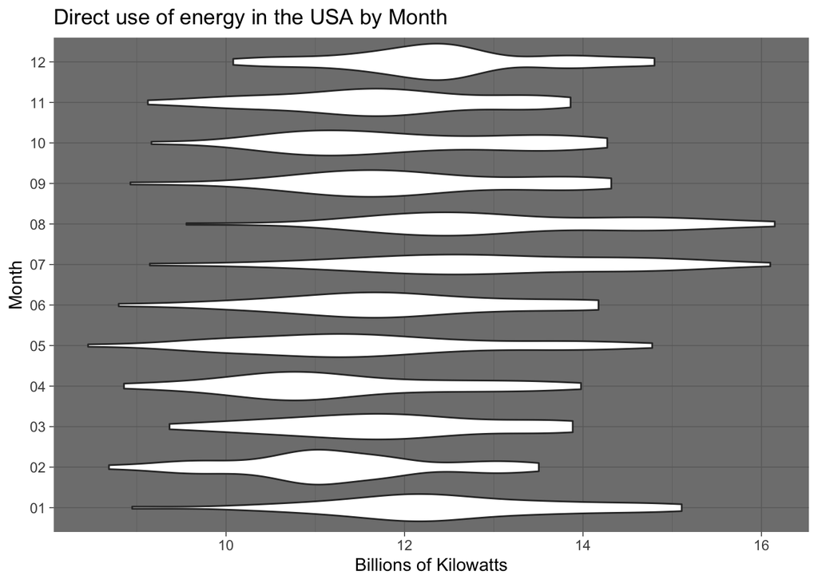

```r
graph1
```

```r
cD <- na.omit(map2_dfr(spData$`Electricity Exports`,substr(spData[,2],5,6),~ tibble(Exp = .x, Month = .y)))
cD
```

```
## # A tibble: 643 x 2
##      Exp Month
##    <dbl> <chr>
##  1 0.175 13
##  2 0.147 13
##  3 0.2   13
##  4 0.237 13
##  5 0.429 13
##  6 0.348 13
##  7 0.5   13
##  8 0.631 13
##  9 1.25  13
## 10 0.76  13
## # … with 633 more rows
```

```r
cD <- arrange(cD,desc(Month))
cD
```

```
## # A tibble: 643 x 2
##      Exp Month
##    <dbl> <chr>
##  1 0.175 13
##  2 0.147 13
##  3 0.2   13
##  4 0.237 13
##  5 0.429 13
##  6 0.348 13
##  7 0.5   13
##  8 0.631 13
##  9 1.25  13
## 10 0.76  13
## # … with 633 more rows
```

```r
cD <- cD[72:643,]
g2 <- ggplot(cD ,aes(Exp,Month)) +geom_violin() + theme_dark() + labs(x = "Billions of Kilowatts", y = "Month", title = "Energy exports in the USA by Month from 1950-2020")
```

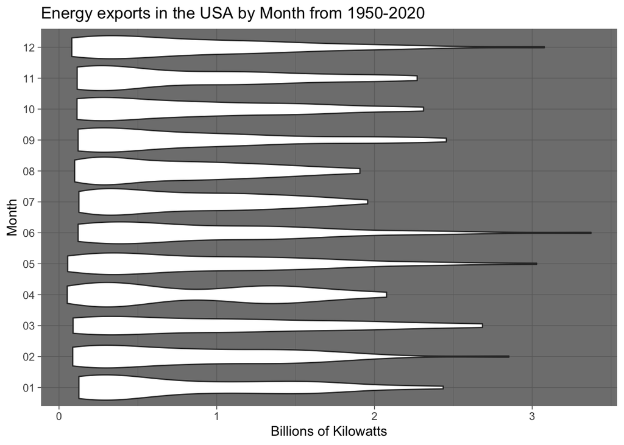

```r
g2
```

```r
dD <- na.omit(map2_dfr(spData$`Electricity Imports`,substr(spData[,2],5,6),~ tibble(Exp = .x, Month = .y)))
dD
```

```
## # A tibble: 643 x 2
##      Exp Month
##    <dbl> <chr>
##  1  1.76 13
##  2  1.93 13
##  3  2.39 13
##  4  2.51 13
##  5  2.44 13
##  6  2.69 13
##  7  4.57 13
##  8  5.18 13
##  9  4.86 13
## 10  4.08 13
## # … with 633 more rows
```

```r
dD <- arrange(dD,desc(Month))
dD <- dD[72:643,]
dD
```

```
## # A tibble: 572 x 2
##      Exp Month
##    <dbl> <chr>
##  1 1.43  12
##  2 1.31  12
##  3 0.957 12
##  4 0.931 12
##  5 1.71  12
##  6 1.80  12
##  7 1.91  12
##  8 2.12  12
##  9 3.08  12
## 10 2.99  12
## # … with 562 more rows
```

```r
g3 <- ggplot(dD ,aes(Exp,Month)) +geom_violin() + theme_dark() + labs(x = "Billions of Kilowatts", y = "Month", title = "Energy imports in the USA by Month from 1950-2020")
```

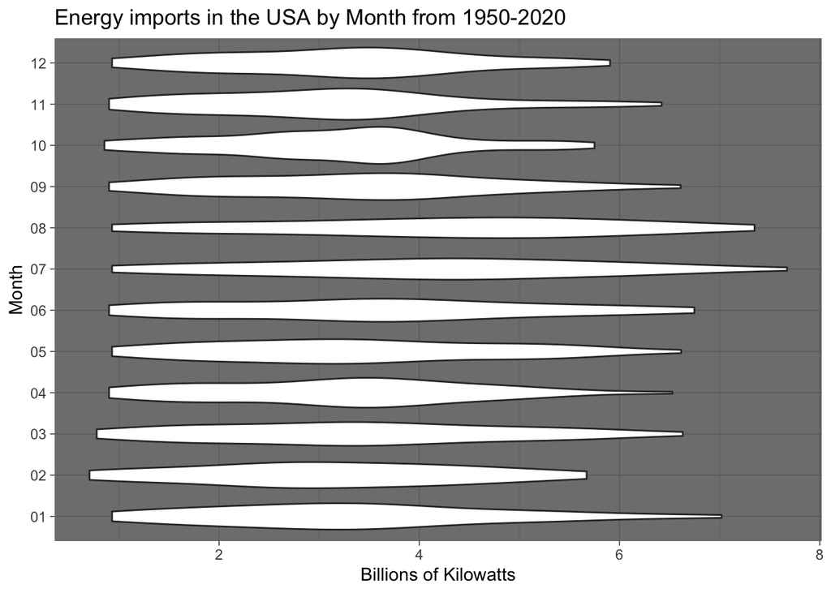

```r
g3
```

```r
eD <- na.omit(map2_dfr(spData$`Electricity Net Generation, Total`,substr(spData[,2],5,6),~ tibble(Exp = .x, Month = .y)))
eD
```

```
## # A tibble: 643 x 2
##      Exp Month
##    <dbl> <chr>
##  1  296. 13
##  2  334. 13
##  3  375. 13
##  4  404. 13
##  5  447. 13
##  6  476. 13
##  7  550. 13
##  8  604. 13
##  9  635. 13
## 10  648. 13
## # … with 633 more rows
```

```r
eD <- arrange(eD,desc(Month))
eD <- eD[72:643,]
g4 <- ggplot(eD ,aes(Exp,Month)) +geom_violin() + theme_dark() + labs(x = "Billions of Kilowatts", y = "Month", title = "Energy net Generation in the USA by Month from 1950-2020")
```

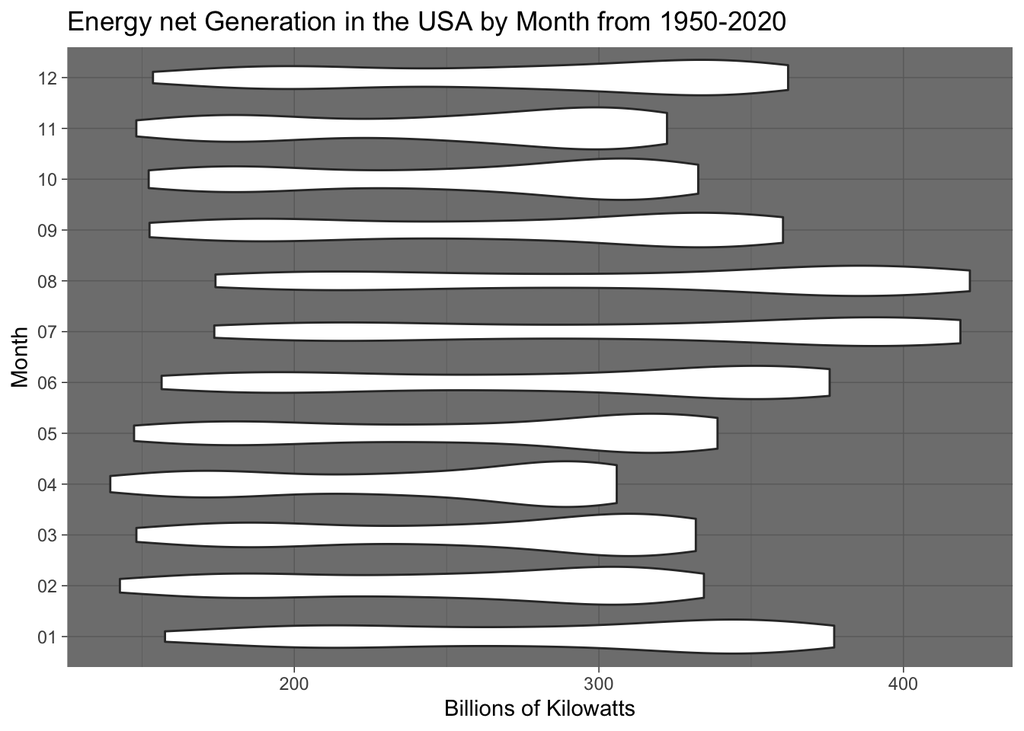

```r
g4
```

```r
fD <- na.omit(map2_dfr(spData$`Transmission and Distribution Losses and Unaccounted for`,substr(spData[,2],5,6),~ tibble(Exp = .x, Month = .y)))
fD
```

```
## # A tibble: 643 x 2
##      Exp Month
##    <dbl> <chr>
##  1  43.2 13
##  2  44.4 13
##  3  47.2 13
##  4  49.9 13
##  5  52.8 13
##  6  54.4 13
##  7  57.6 13
##  8  62.1 13
##  9  62.4 13
## 10  63.9 13
## # … with 633 more rows
```